# Homework 2

Ziyang (Bob) Ding

28 January, 2020

## Problem 1

**When applying rejection sampling sampling to a posterior distribution $\pi(\theta | y) \propto \pi_{0}(\theta) f(y | \theta)$ using as candidate density the prior $\pi_{0}(\theta),$ show that the bound $c$ can be taken to be the likelihood function evaluated at the MLE.**

**Proof**

In short, we want to show that
$$\begin{aligned}
f(y | \hat{\theta}_{MLE})\pi_0(\theta) &\geq \pi(\theta | y)\\
&= \frac{\pi_0(\theta) f(y | \theta)}{p(y)}\\
f(y | \hat{\theta}_{MLE}) &\geq \frac{f(y | \theta)}{p(y)}\\
\Longleftrightarrow f(y | \hat{\theta}_{MLE}) - \frac{f(y | \theta)}{p(y)} &\geq 0\\
\Longleftrightarrow \inf (f(y | \hat{\theta}_{MLE}) - \frac{f(y | \theta)}{p(y)}) &\geq 0\\
\end{aligned}$$

Then, we can take derivative to find out the infimum of the left hand side:

$$\begin{aligned}
\frac{\partial (f(y | \hat{\theta}_{MLE}) - \frac{f(y | \theta)}{p(y)})}{\partial \theta} = - \frac{\partial f(y | \theta)}{ p(y)\partial \theta} = 0\\
\end{aligned}$$

If MLE exist, then we know that the left hand side take infimum at $\theta = \hat{\theta}_{MLE}$. Then

$$\begin{aligned}
\inf (f(y | \hat{\theta}_{MLE}) - \frac{f(y | \theta)}{p(y)}) &= f(y | \hat{\theta}_{MLE}) - \frac{f(y | \hat{\theta}_{MLE})}{p(y)}\\
&= f(y | \hat{\theta}_{MLE})(1 - \frac{1}{p(y)}) \geq 0
\end{aligned}$$
Therefore, we know that the constant $c$ can be taken to be the likelihood function evaluated at the MLE.

## Problem 2

**$(\mathrm{RC} 3.1-2)$ For the normal-Cauchy Bayes estimator**
$$\begin{aligned}
\delta(x)=\frac{\int_{-\infty}^{\infty} \frac{\theta}{1+\theta^{2}} e^{-\frac{1}{2}(x-\theta)^{2}} d \theta}{\int_{-\infty}^{\infty} \frac{1}{1+\theta^{2}} e^{-\frac{1}{2}(x-\theta)^{2}} d \theta}
\end{aligned}$$

- 1. **Plot the integrand and use Monte Carlo integration to calculate the integral.**

**Proof**

First, I have a question about this problem: when we are plotting the integrand, we can notice that the integrand is actually a function that depends both x and $\theta$. I don’t how we’re plotting this 2 dimensional function. Therefore, I directly plotted the delta for all the x.

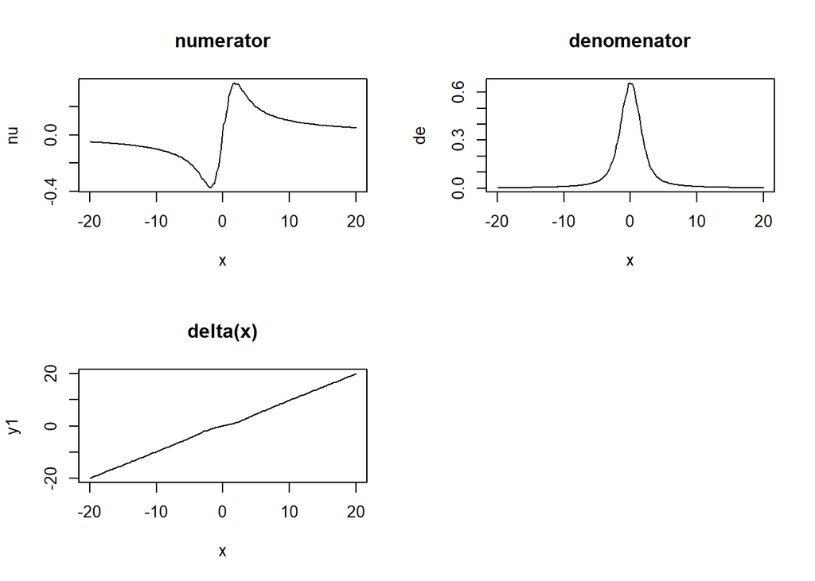

```r
# Monte Carlo Integration on the nominator
f11 = function(x, n = 1000){
  theta = rnorm(n, x, 1)
  int1 = mean(theta/(1+theta^2))
  return(mean(int1))
}

# Monte Carlo Integration on the denominator
f12 = function(x, n = 1000){
  theta = rnorm(n, x, 1)
  int2 = mean(1/(1+theta^2))
  return(mean(int2))
}

f11 = Vectorize(f11)
f12 = Vectorize(f12)

# Get 200 xs
x = seq(-20,20,length.out = 200)
nu = f11(x)
de = f12(x)

f1 = function(x, n = 1000){
  theta = rnorm(n, x, 1)
  int1 = mean(theta/(1+theta^2))
  int2 = mean(1/(1+theta^2))
  return(int1/int2)
}


f1 = Vectorize(f1)

y1 = f1(x)


par(mfrow=c(2,2))
plot(x, nu, main = 'numerator', type='l')
plot(x, de, main = 'denomenator', type='l')
plot(x, y1, main = 'delta(x)', type = 'l')
```

- 2. **Monitor the convergence with the standard error of the estimate. Obtain 3 digits of accuracy with probability. 95**

**Proof**

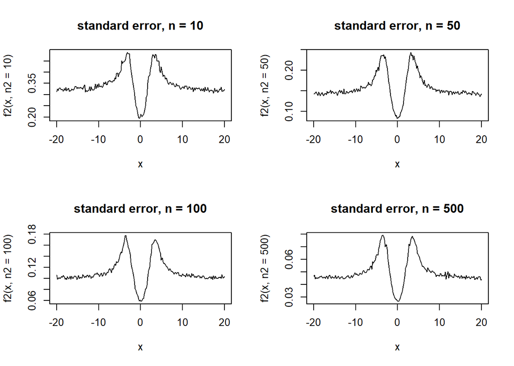

```r
f2 = function(x, n1 = 1000, n2 = 100){
  y1 = rep(0, n1)
  for(i in 1:n1){
    y1[i] = f1(x, n2)
  }
  return(sd(y1))
}


f2 = Vectorize(f2)

par(mfrow = c(2,2))
plot(x, f2(x, n2 = 10), main = 'standard error, n = 10', type = 'l')
plot(x, f2(x, n2 = 50), main = 'standard error, n = 50', type = 'l')
plot(x, f2(x, n2 = 100), main = 'standard error, n = 100', type = 'l')
plot(x, f2(x, n2 = 500), main = 'standard error, n = 500', type = 'l')
```

```r
print(round(f1(1, 1e8), 3))
```

```
## [1] 0.554
```

- 3. **Use rejection sampling with a Cauchy candidate distribution to generate a sample from the posterior distribution and calculate the estimator.**

**Proof**
$$\begin{aligned}
\frac{p(\theta | x)}{p(\theta)} &=\frac{\frac{1}{\sqrt{2 \pi}} e^{-\frac{1}{2}(x-\theta)^{2}}}{\int \frac{1}{\pi\left(1+\theta^{2}\right)} \frac{1}{\sqrt{2 \pi}} e^{-\frac{1}{2}(x-\theta)^{2}} d \theta} \leq 2
\end{aligned}$$

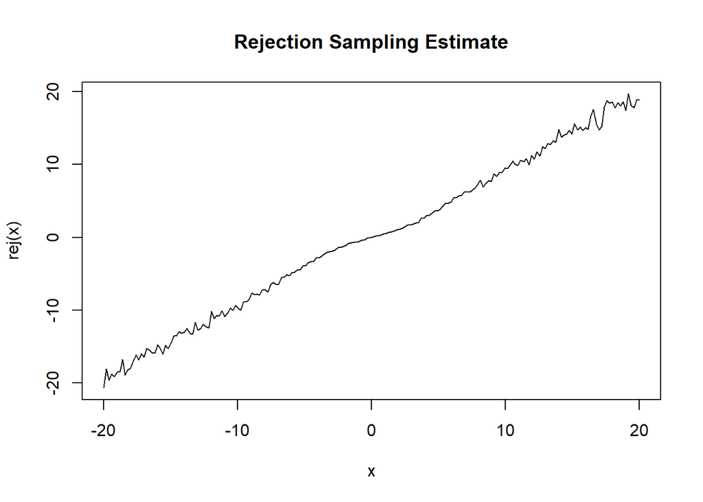

```r
rej = function(x, n = 1000, M = 2){
  sample = rep(0, n)
  theta = rnorm(1000,x,1)
  int = mean(1/(pi*(1+theta^2)))
  j = 1
  for(i in 1:n){
    cand = rcauchy(1)
    u = runif(1)
    if(u <= dnorm(cand, x, 1)/(M*int)){
      sample[j] = cand
          j = j+1
    }
  }
  return (mean(sample[1:(j-1)]))
}

rej = Vectorize(rej)

x = seq(-20, 20, length = 200)

plot(x, rej(x), main='Rejection Sampling Estimate', type = 'l')
```

- 4. **Design a computer experiment to compare Monte Carlo error when using**
- 1. **the same random variables $\theta_{i}$ in numerator and denoninator, or**
- 2. **different random variables.**

**Proof**

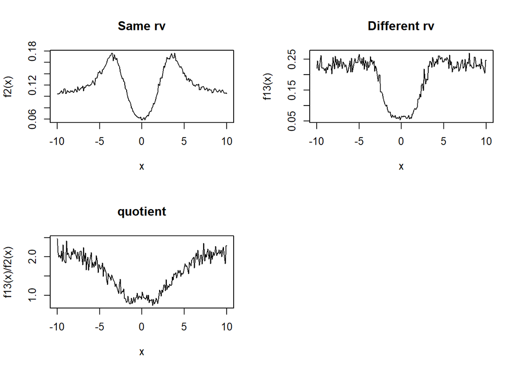

```r
f13 = function(x, n1 = 100, n2 = 100){
   y1 = rep(0, n1)
   y2 = rep(0, n1)
  for(i in 1:n1){
    y1[i] = f11(x, n2)
    y2[i] = f12(x, n2)
  }
  return(sd(y1/y2))
}


f13 = Vectorize(f13)

par(mfrow = c(2,2))
x = seq(-10, 10, length.out = 200)
plot(x, f2(x), main = 'Same rv', type='l')
plot(x, f13(x), main = 'Different rv', type='l')
plot(x, f13(x)/f2(x), main = 'quotient', type='l')
```

Two different actually agrees much around $x = 0$. However, when $x$ becomes larger, using the same random variable leads to lower standard deviation. Especially when you see that when $x=10$ the standard deviation is around half of the other method.

## Problem 3

- 1. **For a standard normal random variable $Z,$ calculate $P(Z>2.5)$ using Monte Carlo sums based on indicator functions. How many simulated random variables are needed to obtain 3 digits of accuracy?**

**Proof**

Because we know that
$$\mathbb{E}[ \frac{\sum_{i=1}^n \mathrm{1}(X_i > 2.5)}{n}] = \mathbb{P}(X \geq 2.5)$$

Also, $\mathbb{E}[ \frac{\sum_{i=1}^n \mathrm{1}(X_i > 2.5)}{n}] \in L_1, L_2$. Therefore we can apply the Chebyshev inequality here.

$$\begin{aligned}
X &\sim N(0,1)\\
\mathbb{P} (\left|\frac{\sum_{i=1}^n \mathrm{1}(X_i > 2.5)}{n} - \mathbb{P}(X \geq 2.5) \right| \geq 10^{-3}) &\leq \frac{\mathrm{Var}\left(\frac{\sum_{i=1}^n \mathrm{1}(X_i > 2.5)}{n} \right)}{10^{-6}}\\
\mathbb{P} (\left|\frac{\sum_{i=1}^n \mathrm{1}(X_i > 2.5)}{n} - \mathbb{P}(X \geq 2.5) \right| \leq 10^{-3}) &\geq 1- \frac{\mathrm{Var}\left(\frac{\sum_{i=1}^n \mathrm{1}(X_i > 2.5)}{n} \right)}{10^{-6}}\\
\end{aligned}$$

This is from Chebyshev. To ensure 0.95 probability of convergence of the error within 3 digits, we need to have that

$$\begin{aligned}
1- \frac{\mathrm{Var}\left(\frac{\sum_{i=1}^n \mathrm{1}(X_i > 2.5)}{n} \right)}{10^{-6}} &\geq 0.95\\
\frac{\mathrm{Var}\left(\frac{\sum_{i=1}^n \mathrm{1}(X_i > 2.5)}{n} \right)}{10^{-6}} &\leq 0.05\\
\mathrm{Var}\left(\frac{\sum_{i=1}^n \mathrm{1}(X_i > 2.5)}{n} \right) &\leq 5 \times 10^{-8}
\end{aligned}$$

We may denote $\mathbb{P}(X > 2.5) = p$. Therefore we have

$$\begin{aligned}
\frac{np(p-1)}{n^2} &\leq 5 \times 10^{-8}\\
n &\geq 2 \times 10^{7} p(1-p)\\
\end{aligned}$$

```r
p = 1 - pnorm(0.25)
p*(1-p) * 2 * (10^7)
```

```
## [1] 4805141
```

- 2. **Using Monte Carlo sums verify that if $X \sim \operatorname{Gam}(1,1), P(X>5.3) \approx .005 .$ Find the exact .995 cutoff to three digits of accuracy.**

**Proof**

```r
ga = function(a, n=1000){
  x = rgamma(n, 1, 1)
  return (mean(x>a))
}
1-ga(5.3, 1e7)
```

```
## [1] 0.9949743
```

```r
ga1 = function(n=1000){
  x = rgamma(n, 1, 1)
  return (quantile(x, 0.995))
}

ga1 = Vectorize(ga1)
x = 10^c(3,4,5,6,7)
ga1(x)
```

```
##    99.5%    99.5%    99.5%    99.5%    99.5%
## 5.685435 5.114384 5.260158 5.312908 5.302725
```

```r
qgamma(0.995, 1, 1)
```

```
## [1] 5.298317
```

We see that $\mathbb{P}(X > 5.3) \approx 0.005$. The cutoff is around 5.298.

## Problem 4

- 1. **In class we discussed the optimal instrumental distribution for importance sampling, which is often impractical. Show that if we use the renormalized weight estimator ( $\tilde{\theta}$ from class), we get**

$$\begin{aligned}
\tilde{\theta}=\frac{\sum_{i=1}^{m} h\left(x^{(i)}\right)\left|h\left(x^{(i)}\right)\right|^{-1}}{\sum_{i=1}^{m}\left|h\left(x^{(i)}\right)\right|^{-1}}
\end{aligned}$$

**Proof**

- 2. **Compare (in a simulation experiment) the performance of the regular Monte Carlo estimator of**
     $$\begin{align*}
     \int_{1}^{2} \frac{e^{-\frac{x^{2}}{2}}}{\sqrt{2 \pi}} d x=\Phi(2)-\Phi(1)
     \end{align*}$$
     **with that of an estimator based on an optimal choice of instrumental distribution.**

**Proof**

```r
correct = pnorm(2)-pnorm(1)
correct
```

```
## [1] 0.1359051
```

```r
# Importance sampling
n=460000
U = runif(n,1,2)
mean((exp(-0.5*U^2)/sqrt(2*pi)))
```

```
## [1] 0.1359129
```

```r
# Monte Carlo
p=pnorm(2)-pnorm(1)
(qnorm(0.975)^2*p*(1-p)/(0.001)^2)
```

```
## [1] 451121.4
```

```r
MC = function(n){
  x = rnorm(n)
  return (sum(x<2 & x>1)/n)
}

MC(460000)
```

```
## [1] 0.1351457
```

: Importance sampler is better than monte carlo. With the same sample size, importance sampler is more accurate.